# STAT 428: Homework 1 Solution: Testing Rmd and homework submission

Xin, Huiqin, huiqinx2 Collaborated with: Ravat, Uma, ravat1

Please refer to the [**detailed homework policy document**](https://compass2g.illinois.edu/bbcswebdav/pid-3028361-dt-content-rid-31752712_1/courses/stat_428_120181_161673/1_Info/Syllabus/homework_policy.html) on Course Page for information about homework formatting, submission, and grading.

Your first homework is to get up to speed with writing documents in RMarkdown and to familiarize yourselves the HW submission format and process. There are `10 points` for proper formatting since this is the first homework.

## Solution for Exercise 1:

`5 points` Your tasks!

- Save this `.Rmd` file using the naming conventions for homework assignments.
- Open the file in RStudio
- Change the name of the author above to yours
- Add any collaborators anytime you have worked with someone on this assignment
- Click Knit HTML
- After doing all the above steps, add an appropriate section marked `Solution` for Exercise 1, remove any unnecessary text that should not be included in the report and a sentence to your solution section so that your report states that you have followed the tasks listed in Exercise 1.

I have followed the tasks listed in Exercise 1.

## Solution for Exercise 2:

`20 points` This exercise has several parts about RMarkdown syntax. You may look into the [Scribing Reference](https://compass2g.illinois.edu/bbcswebdav/pid-3451622-dt-content-rid-37508958_1/courses/stat_428_120191_169827/1_Info/Syllabus/Tutorial/2A_RMarkdown_Tutorial.html) as you work through this exercise.

1. Write two sentences below about yourself. `1 points`

My name is Huiqin Xin. I am the TA for Stat 428.

2. Copy and paste the above two sentences. Make one sentence **bold** and the other *italic*. Separate the two sentences by a blank line. `2 points`

**My name is Huiqin Xin.**

*I am the TA for Stat 428.*

3. What’s your favorite website? `2 points`
   1. Create a hyperlink anchored to text ‘My favorite website’ to your favorite website: [My favorite website](http://www.google.com)
   2. Create a hyperlink anchored by the URL to your favorite website: http://www.google.com
4. What character is used to denote headers?`1 points`

The **#** sign is used to denote headers.

5. Write a quoted statistics or probability joke. *(Remember, to acknowlege the reference to where you found the joke)*. `1 points`

Two unbiased estimators were sitting in a bar. The first said, “So how do you like married life?” The other replies, “It’s pretty good if you don’t mind giving up that one degree of freedom!” [Source](http://www.maths.usyd.edu.au/u/jchan/Statistic_joke.pdf)

6. Write Computer Type for running 2+3 in R. `1 points`

`2+3`

7. Write a bulleted list of top 3 reasons you chose this course. `2 points`
- first reason
- second reason
- thid reason
8. Write an itemized list of your top three fears in this course. You may use sub-list if necessary! `2 points`
   1. fear1.
   2. fear2.
   3. fear3.

**Note: You need to indent with 4 blank spaces.**

9. Find an image on web or create one using R, of the hypergeometric distribution. Insert the image here. `1 points`

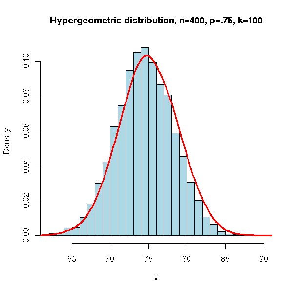

Hypergeometric Distribution

10. Can you find a way to resize the image in RMarkdown? `1 points`

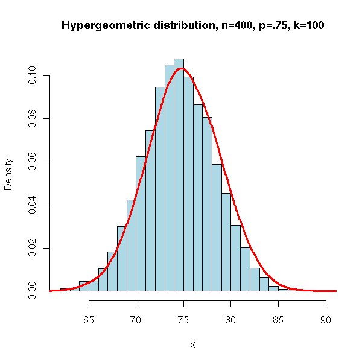

11. Write three separate code chunks named A, B, C where `3 points`
- code chunk A shows only results but no code

  ```
  ## [1] 5
  ```

- code chunk B shows only the code but does not run it

  ```r
    2+3
  ```

- code chunk C neither shows the code nor the results but does run the code
12. Using Latex, write the equation for the likelihood function $L(\theta)$ that corresponds to $n$ i.i.d Bernoulli random variables $X_i$. `2 points`

$$L(\theta) = \theta^{\sum_{i=1}^n x_i}(1-\theta)^{n-\sum_{i=1}^n x_i}$$

13. Describe in one sentence your experience doing this exercise. `1 points`

This was a nice oppurtunity to brush up on several R markdown formats.

## Solution for Exercise 3:

`5 points` Mark whether the following statements pertaining to this class are True or False. If False, make sure you know what the true statement is. You may need to refer to the Syllabus to answer the following questions.

1. **True**: Piazza should be used as much as possible for questions pertaining to course administration and general course information.
2. **False**: Email is the fastest way to get questions related to homework as well as general questions answered.
3. **False**: The exam dates and location are
   - Exam 1: Week 7, Wednesday, Feb 27, in class
   - Exam 2: Week 15, Friday, April 26, in class
4. **False**: Homework and exams can be eaisly made up after the deadline by sending an email to the instructor or the TA requesting this. Such emails will be answered instantly.
5. **False**: The project will be a group project and will have only one deadline: May 03, 2019.

## Solution for Exercise 4:

`30 points` **Simple R questions:** R has a built-in matrix of different types of data of every US state, `state.x77`. Use this matrix and R’s built in functions and **vector calculation** to perform the following tasks. You will also need `rownames(state.x77)` to get the state names and R’s character functions to manipulate them (refer [here](http://www.statmethods.net/management/functions.html) or google).

1. What is the longest state name (including spaces) and how long is it? `5 points`

```
## [1] "North Carolina" "South Carolina"
```

The longest state names are North Carolina and South Carolina. They have a length of 14.

2. List all the states that are more then one word. How many are there? `5 points`

```
##  [1] "New Hampshire"  "New Jersey"     "New Mexico"     "New York"
##  [5] "North Carolina" "North Dakota"   "Rhode Island"   "South Carolina"
##  [9] "South Dakota"   "West Virginia"
```

There are 10 state names with more than one word in them.

3. List all the US State names, where all of the upper and lower case `a's` are replaced with a capital `Z`. `5 points`

```
##  [1] "ZlZbZmZ"        "ZlZskZ"         "ZrizonZ"        "ZrkZnsZs"
##  [5] "CZliforniZ"     "ColorZdo"       "Connecticut"    "DelZwZre"
##  [9] "FloridZ"        "GeorgiZ"        "HZwZii"         "IdZho"
## [13] "Illinois"       "IndiZnZ"        "IowZ"           "KZnsZs"
## [17] "Kentucky"       "LouisiZnZ"      "MZine"          "MZrylZnd"
## [21] "MZssZchusetts"  "MichigZn"       "MinnesotZ"      "Mississippi"
## [25] "Missouri"       "MontZnZ"        "NebrZskZ"       "NevZdZ"
## [29] "New HZmpshire"  "New Jersey"     "New Mexico"     "New York"
## [33] "North CZrolinZ" "North DZkotZ"   "Ohio"           "OklZhomZ"
## [37] "Oregon"         "PennsylvZniZ"   "Rhode IslZnd"   "South CZrolinZ"
## [41] "South DZkotZ"   "Tennessee"      "TexZs"          "UtZh"
## [45] "Vermont"        "VirginiZ"       "WZshington"     "West VirginiZ"
## [49] "Wisconsin"      "Wyoming"
```

4. Output only the second column of the matrix and store it in the numeric vector `capita`. This vector indicates the per capita income (1974) of every US states. `2 points`
5. What is the average per-capita income of the US (1974)? `3 points`

The average per-capita income of US (1974) is $4435.8.

6. What is the average per-capita income of the states that have names that are more than one word? `5 points`

The average per-capita income of states that have names that are more than one word is $4296.1.

7. Which state has the highest per-capita income? `5 points`

Alaska has the highest per-capita income.

# Solution for Exercise 5:

1. Define a random variable $X$. `2 points`

A variable $X$ is a list of values $x$ together with a probability with which those values occur.

2. What are the types of random variables? `2 points`

Discrete and continuous

3. What is a distribution of a random variable? `2 points`

A description of how the probability of a random variable over its possible values.

4. Define the pmf, pdf, and cdf of a random variable. `3 points`

pmf ($p(x)$): probability mass function, which only applies to discrete random variables. $p(x)=P(X=x)$ gives the probability that a discrete random variable equals $x$.  
pdf ($f(x)$): probability distribution function. $\int_a^b f(x)$ gives the probability that a random variable is between the values $a$ and $b$.  
cdf ($F(x)=P(X\leq x)$): cummulative distribution function. Gives the probability that a random variable is less than or equal to $x$.

5. Define the expected value $E[X]$, variance $V[X]$ and mode of a random variable $X$. `3 points`

Let $f(x)$ be a probability distribution function.

$E[X] = \int_{-\infty}^{\infty}xf(x)dx$ for continuous or $E[X] = \Sigma_{x:p(x)>0} xf(x)$ for discrete RV  
$V[X] = E[X^2]-E[X]^2$  
$V[X]= \int_{-\infty}^{\infty}x^2f(x)dx-(\int_{-\infty}^{\infty}xf(x)dx)^2$ for continuous variables, and similar for discrete.

The mode is the value with the highest probability, or the value most likely to occur.

6. Give examples of two discrete and two continuous random variables. Include their distribution functions, expected value and variance. `4 points`

See [this reference from Texas A&M University](http://www.stat.tamu.edu/~twehrly/611/distab.pdf) for a full list of the common distributions, the means, and variances.

7. Plot the above random variables in `R`. `4 points`

For example, a discrete variable (Binom(5,0.5)):

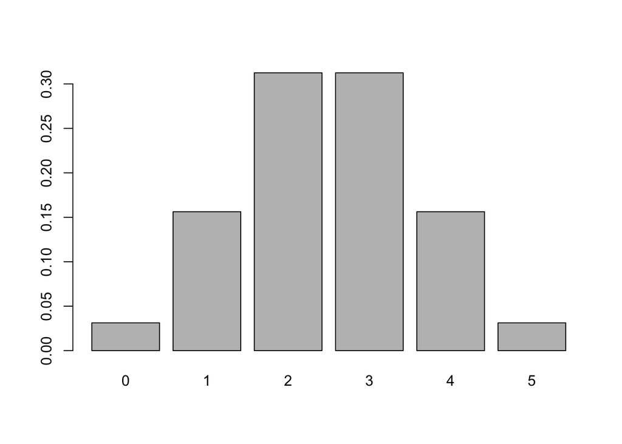

A continuous variable (N(0,2)):

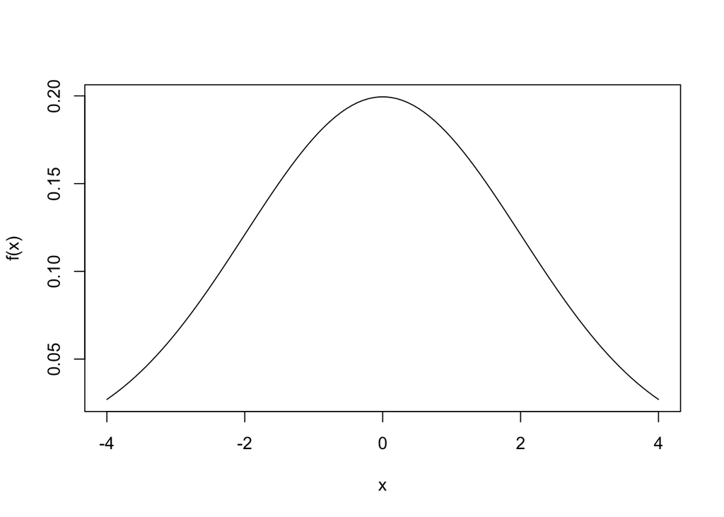

Students need to provide two of each.

## Sampling distributions and estimation

`20 points`

8. What are i.i.d random variables? What is a random sample? `2 points`

Independent and identically distributed random variables. $\lbrace X_1,\cdots , X_n\rbrace$ are a random sample if $\lbrace X_1,\cdots , X_n\rbrace$ are i.i.d.

9. What is a statistic? Can you give two examples? `3 points`

A function of a sample: $T_n=T(X_1,\cdots,X_n)$. Two examples would be the sample mean ($\overline{X}=\Sigma_{i=1}^nX_i$) and sample variance ($S^2=\frac{1}{n-1}\Sigma_{i=1}^n(X_i-\overline{X})^2$).

10. What is an estimator $\theta$? Can you give two examples? `3 points`

An estimator is a function of the data that attempts to estimate a parameter. $\hat{\theta}$ would be an estimator of $\theta$. Two examples: $\overline{X}$ is an estimator for $\mu$ (the population mean) and $S^2$ is an estimator for $V[X]$.

11. What is the bias of an estimator $bias(\hat\theta)$? `2 points`

Bias$(\hat\theta)=E[\hat{\theta}]-\theta$

12. What is the variance (Var), standard error (se) of an estimator $\hat\theta$? `2 points`

The variance of $\hat\theta$ is the expected variance of the estimator. The standard error is the square root of the variance.

13. What is Mean Square Error of an estimator $\hat\theta$? `2 points`

MSE$(\hat\theta)=Var(\hat\theta)+[bias(\hat\theta)]^2$

14. What is the relation between $MSE(\hat\theta)$ and $bias(\hat\theta)$? `2 points`

See formula above. The MSE equals to the variance of the estimator if the estimator is unbiased.

15. What do the methods of MOM and MLE help you do? You can explain it by an example. `2 points`

Methods of moments and MLE help to develop estimators for $\theta$.

16. Give an application example that would require you to use one of these estimation techniques. `2 points`

Consider trying to estimate the median age of dogs at a dog park. You would need to take a random sample of dogs to get i.i.d observations of their ages. Then you would need to develop an estimator of $\theta$, the population median.